# Snow Gauge Calibration

\[ \newcommand{\Prob}{\operatorname{P}} \newcommand{\E}{\operatorname{E}} \newcommand{\Var}{\operatorname{Var}} \newcommand{\Cov}{\operatorname{Cov}} \newcommand{\se}{\operatorname{se}} \newcommand{\re}{\operatorname{re}} \newcommand{\ybar}{{\overline{Y}}} \newcommand{\phat}{{\hat{p}}} \newcommand{\that}{{\hat{T}}} \newcommand{\med}{{\tilde{Y}}} \newcommand{\Logit}{{\operatorname{Logit}}} \]

## Introduction

## Data

| Density | G 01 | G 02 | G 03 | G 04 | G 05 | G 06 | G 07 | G 08 | G 09 | G 10 |
| --- | --- | --- | --- | --- | --- | --- | --- | --- | --- | --- |
| 0.686 | 17.6 | 17.3 | 16.9 | 16.2 | 17.1 | 18.5 | 18.7 | 17.4 | 18.6 | 16.8 |
| 0.604 | 24.8 | 25.9 | 26.3 | 24.8 | 24.8 | 27.6 | 28.5 | 30.5 | 28.4 | 27.7 |
| 0.508 | 39.4 | 37.6 | 38.1 | 37.7 | 36.3 | 38.7 | 39.4 | 38.8 | 39.2 | 40.3 |
| 0.412 | 60.0 | 58.3 | 59.6 | 59.1 | 56.3 | 55.0 | 52.9 | 54.1 | 56.9 | 56.0 |
| 0.318 | 87.0 | 92.7 | 90.5 | 85.8 | 87.5 | 88.3 | 91.6 | 88.2 | 88.6 | 84.7 |
| 0.223 | 128.0 | 130.0 | 131.0 | 129.0 | 127.0 | 129.0 | 132.0 | 133.0 | 134.0 | 133.0 |
| 0.148 | 199.0 | 204.0 | 199.0 | 207.0 | 200.0 | 200.0 | 205.0 | 202.0 | 199.0 | 199.0 |
| 0.080 | 298.0 | 298.0 | 297.0 | 288.0 | 296.0 | 293.0 | 301.0 | 299.0 | 298.0 | 293.0 |
| 0.001 | 423.0 | 421.0 | 422.0 | 428.0 | 436.0 | 427.0 | 426.0 | 428.0 | 427.0 | 429.0 |

## Log Gain by Gauge

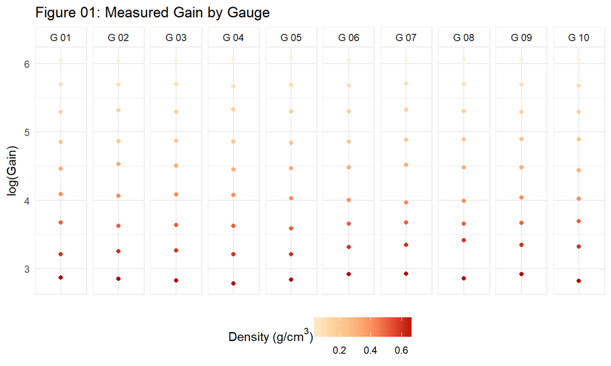

## Gauge and Density Relationship

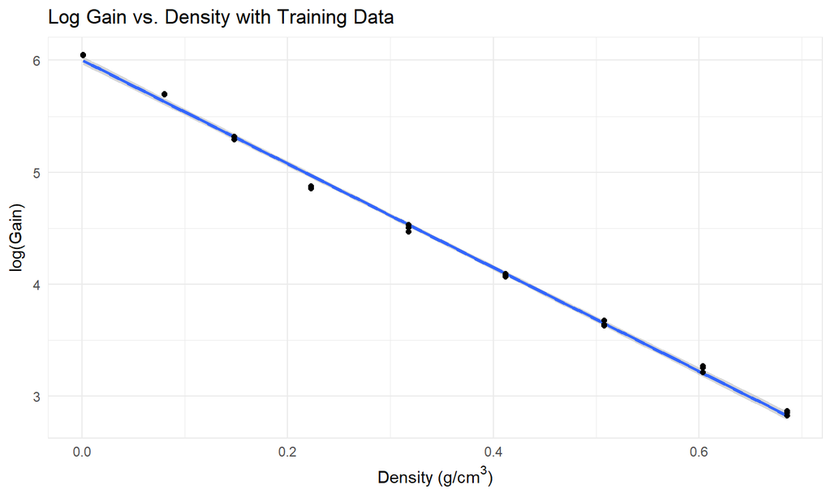

## Classic Calibration

## Classic Calibration Method

Let: \[ G := \text{Gain}, D := \text{Density} \] \[ \ln(G) = f(D) \]

|  | Estimate | Std. Error | t value | Pr(>\|t\|) |
| --- | --- | --- | --- | --- |
| **(Intercept)** | 6.003 | 0.01799 | 333.6 | 3.897e-47 |
| **Density** | -4.63 | 0.04495 | -103 | 2.182e-34 |

Fitting linear model: log(Gain) ~ Density

| Observations | Residual Std. Error | \(R^2\) | Adjusted \(R^2\) |
| --- | --- | --- | --- |
| 27 | 0.05255 | 0.9976 | 0.9976 |

## Classic Calibration Inversion

\[ \hat{D_{i}} = -\frac{\ln(G_{i}) - 6.0032 - \epsilon_{i}}{4.6301} = 1.2965(1+\epsilon_{i}) - 0.2160\ln(G_{i}), \epsilon_{i} \stackrel{iid}{\sim} \mathcal{N}(0,\sigma^{2}) \]

## Classic Calibration Prediction Interval

\[ \se\left( \hat{D_{i}} \right) = \frac{\sqrt{MSE}}{\hat{\beta_{1}}}\sqrt{1 + \frac{1}{n} + \frac{\left( D_{i}-\bar{D} \right)^{2}}{S_{DD}}} \]

| Density | Mean Gain | Est Density | Prediction Std. Error | Prediction LB | Prediction UB |
| --- | --- | --- | --- | --- | --- |
| 0.001 | 428.71429 | -0.0124462 | 0.0141394 | -0.0415669 | 0.0166745 |
| 0.080 | 295.42857 | 0.0679760 | 0.0131343 | 0.0409254 | 0.0950265 |
| 0.148 | 201.71429 | 0.1503875 | 0.0123271 | 0.1249995 | 0.1757756 |
| 0.223 | 131.00000 | 0.2436153 | 0.0117434 | 0.2194293 | 0.2678012 |
| 0.318 | 87.81429 | 0.3300005 | 0.0115588 | 0.3061946 | 0.3538063 |
| 0.412 | 55.75714 | 0.4281015 | 0.0117852 | 0.4038294 | 0.4523736 |
| 0.508 | 38.62857 | 0.5073681 | 0.0122907 | 0.4820549 | 0.5326812 |
| 0.604 | 27.47143 | 0.5809831 | 0.0129879 | 0.5542339 | 0.6077322 |
| 0.686 | 17.61429 | 0.6769713 | 0.0141709 | 0.6477857 | 0.7061569 |

## Classic Calibration Plot

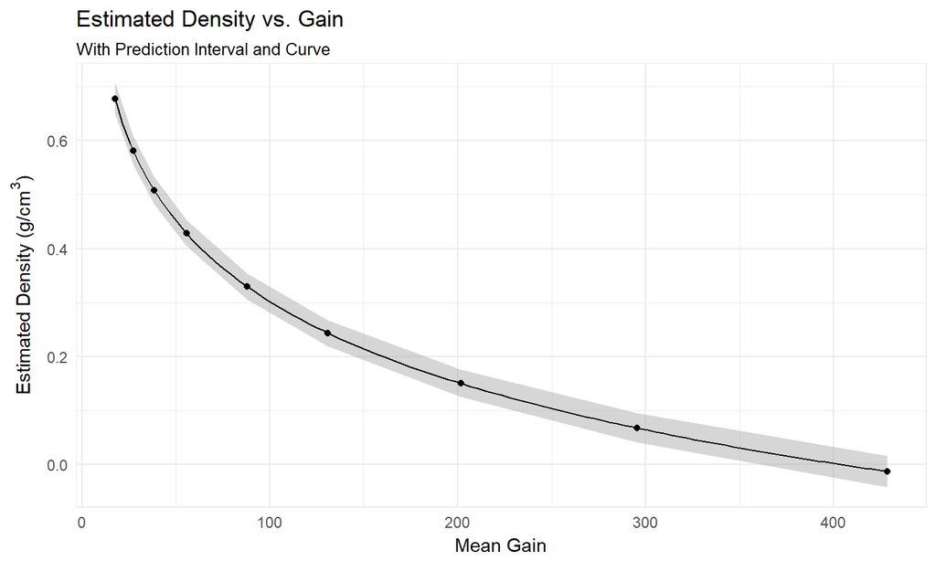

## Classic Calibration Bias

\[ \operatorname{bias}\left( \hat{D_{i}} \right) = \frac{(D_{i} - \bar{D})MSE}{\hat{\beta_{1}}^{2}S_{DD}} \]

| Density | Est Density | Bias | Unbiased Est Density |
| --- | --- | --- | --- |
| 0.001 | -0.0124462 | -0.0001855 | -0.0122607 |
| 0.080 | 0.0679760 | -0.0001411 | 0.0681171 |
| 0.148 | 0.1503875 | -0.0001029 | 0.1504904 |
| 0.223 | 0.2436153 | -0.0000607 | 0.2436760 |
| 0.318 | 0.3300005 | -0.0000074 | 0.3300078 |
| 0.412 | 0.4281015 | 0.0000454 | 0.4280560 |
| 0.508 | 0.5073681 | 0.0000994 | 0.5072687 |
| 0.604 | 0.5809831 | 0.0001533 | 0.5808297 |
| 0.686 | 0.6769713 | 0.0001994 | 0.6767719 |

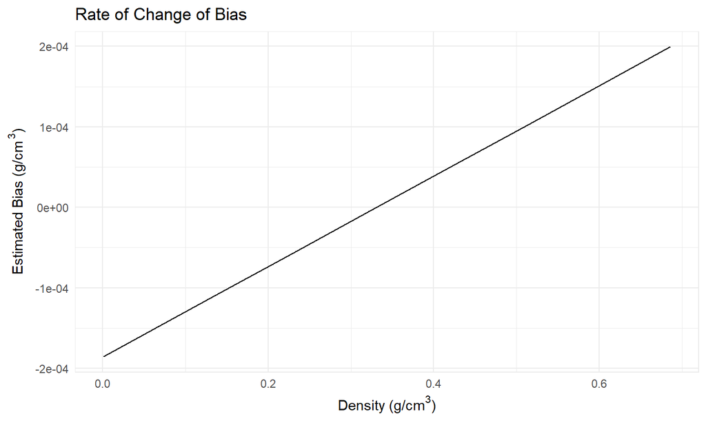

## Inverse Regression

## Inverse Regression Method

\[ \hat{D_{i}} = \hat{\gamma_{0}} + \hat{\gamma_{1}}\left( \ln(G_{i}) - \overline{\ln(G)} \right) + \epsilon_{i}, \epsilon_{i} \stackrel{iid}{\sim} \mathcal{N}(0,\sigma^{2}) \] \[ \overline{\ln(G)} = \sum_{i=1}^{n}\frac{\ln{G_{i}}}{n}, \hat{\gamma_{0}} = \bar{D} \]

|  | Estimate | Std. Error | t value | Pr(>\|t\|) |
| --- | --- | --- | --- | --- |
| **(Intercept)** | 0.3311 | 0.002182 | 151.8 | 1.375e-38 |
| **log(`Centred Gain`)** | -0.2155 | 0.002092 | -103 | 2.182e-34 |

Fitting linear model: Density ~ log(`Centred Gain`)

| Observations | Residual Std. Error | \(R^2\) | Adjusted \(R^2\) |
| --- | --- | --- | --- |
| 27 | 0.01134 | 0.9976 | 0.9976 |

\[ \hat{D_{i}} = 0.3311 - 0.2155\left( \ln(G_{i}) - 4.4701 \right) + \epsilon_{i} \]

## Inverse Regression Prediction Interval

\[ \se\left( \hat{D_{i}} \right) = \sqrt{MSE}\sqrt{1 + \frac{1}{n} + \frac{\left( \ln(G_{i})-\overline{\ln(G)} \right)^{2}}{S_{GG}}} \]

| Density | Mean Gain | Mean Centred Gain | Est Density | Prediction Std. Error | Prediction LB | Prediction UB |
| --- | --- | --- | --- | --- | --- | --- |
| 0.001 | 428.71429 | 4.9072264 | -0.0116386 | 0.0209588 | -0.0548040 | 0.0315268 |
| 0.080 | 295.42857 | 3.3815876 | 0.0685945 | 0.0176857 | 0.0321701 | 0.1050190 |
| 0.148 | 201.71429 | 2.3088983 | 0.1508124 | 0.0147635 | 0.1204064 | 0.1812183 |
| 0.223 | 131.00000 | 1.4994757 | 0.2438210 | 0.0123749 | 0.2183344 | 0.2693075 |
| 0.318 | 87.81429 | 1.0051556 | 0.3300031 | 0.0115453 | 0.3062250 | 0.3537811 |
| 0.412 | 55.75714 | 0.6382174 | 0.4278735 | 0.0125570 | 0.4020119 | 0.4537351 |
| 0.508 | 38.62857 | 0.4421573 | 0.5069538 | 0.0146228 | 0.4768375 | 0.5370700 |
| 0.604 | 27.47143 | 0.3144484 | 0.5803957 | 0.0171798 | 0.5450132 | 0.6157782 |
| 0.686 | 17.61429 | 0.2016198 | 0.6761583 | 0.0210567 | 0.6327912 | 0.7195254 |

## Inverse Regression Plot

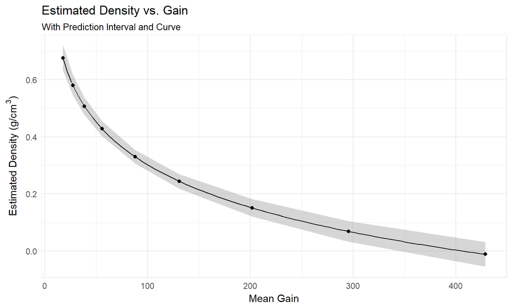

## Inverse Regression Bias

\[ \operatorname{bias}\left( \hat{D_{i}} \right) = \frac{\bar{D} - D_{i}}{1 + \frac{\hat{\beta_{1}}^{2}S_{DD}}{(n-1)MSE}} \]

| Density | Est Density | Bias | Unbiased Est Density |
| --- | --- | --- | --- |
| 0.001 | -0.0116386 | 0.0788687 | -0.0905073 |
| 0.080 | 0.0685945 | 0.0599943 | 0.0086002 |
| 0.148 | 0.1508124 | 0.0437481 | 0.1070643 |
| 0.223 | 0.2438210 | 0.0258294 | 0.2179915 |
| 0.318 | 0.3300031 | 0.0031324 | 0.3268706 |
| 0.412 | 0.4278735 | -0.0193256 | 0.4471991 |
| 0.508 | 0.5069538 | -0.0422615 | 0.5492153 |
| 0.604 | 0.5803957 | -0.0651974 | 0.6455931 |
| 0.686 | 0.6761583 | -0.0847885 | 0.7609467 |

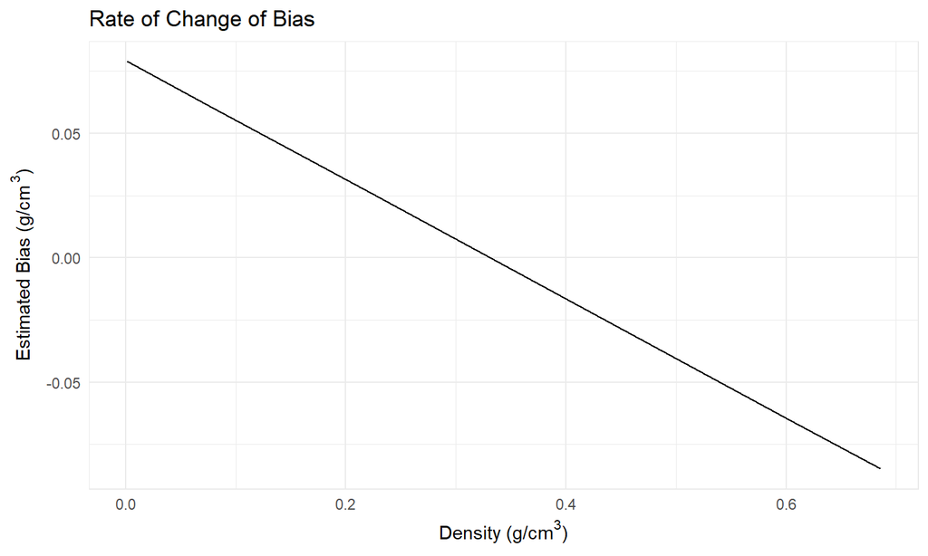

## Comparisons

## Bias

| Density | CC Est Density | CC Bias | IR Est Density | IR Bias |
| --- | --- | --- | --- | --- |
| 0.001 | -0.0124462 | -0.0001855 | -0.0116386 | 0.0788687 |
| 0.080 | 0.0679760 | -0.0001411 | 0.0685945 | 0.0599943 |
| 0.148 | 0.1503875 | -0.0001029 | 0.1508124 | 0.0437481 |
| 0.223 | 0.2436153 | -0.0000607 | 0.2438210 | 0.0258294 |
| 0.318 | 0.3300005 | -0.0000074 | 0.3300031 | 0.0031324 |
| 0.412 | 0.4281015 | 0.0000454 | 0.4278735 | -0.0193256 |
| 0.508 | 0.5073681 | 0.0000994 | 0.5069538 | -0.0422615 |
| 0.604 | 0.5809831 | 0.0001533 | 0.5803957 | -0.0651974 |
| 0.686 | 0.6769713 | 0.0001994 | 0.6761583 | -0.0847885 |

## Standard Error

| Density | Mean Gain | CC Est Density | CC Prediction Std. Error | IR Est Density | IR Prediction Std. Error |
| --- | --- | --- | --- | --- | --- |
| 0.001 | 428.71429 | -0.0124462 | 0.0141394 | -0.0116386 | 0.0209588 |
| 0.080 | 295.42857 | 0.0679760 | 0.0131343 | 0.0685945 | 0.0176857 |
| 0.148 | 201.71429 | 0.1503875 | 0.0123271 | 0.1508124 | 0.0147635 |
| 0.223 | 131.00000 | 0.2436153 | 0.0117434 | 0.2438210 | 0.0123749 |
| 0.318 | 87.81429 | 0.3300005 | 0.0115588 | 0.3300031 | 0.0115453 |
| 0.412 | 55.75714 | 0.4281015 | 0.0117852 | 0.4278735 | 0.0125570 |
| 0.508 | 38.62857 | 0.5073681 | 0.0122907 | 0.5069538 | 0.0146228 |
| 0.604 | 27.47143 | 0.5809831 | 0.0129879 | 0.5803957 | 0.0171798 |
| 0.686 | 17.61429 | 0.6769713 | 0.0141709 | 0.6761583 | 0.0210567 |

## Instructions

## How to Calibrate

1. Place a polyethylene block between the snow gauge and measure take ten measurements of the gain.
2. Calculate the mean gain for the polyethylene block.
3. Using the data set provided, determine if the mean gain falls within the lower and upper bounds for the known density.
- If the gain does not fall within the bounds for the known density, then adjust the gamma ray emission and repeat until the gain falls within the prediction bound.
- If the gain falls within the prediction bound, mark that the gain was accurately read. Repeat the steps with the next block of known densities until all blocks are reading accurately.

## Measurement Error

## Measurement Error

Let: \[ \hat{D_{i}} = D_{i} + \epsilon_{D,i}, \epsilon_{D,i} \sim \mathcal{N}(0, \sigma^{2}) \implies \] \[ \ln(G_{i}) = \hat{\beta_{0}} + \hat{\beta_{1}}\hat{D_{i}} + \epsilon_{G,i} = \hat{\beta_{0}} + \hat{\beta_{1}}(D_{i} + \epsilon_{D,i}) + \epsilon_{G,i} = \] \[ \hat{\beta_{0}} + \hat{\beta_{1}}D_{i} + (\hat{\beta_{1}}\epsilon_{D,i} + \epsilon_{G,i}) = \hat{\beta_{0}} + \hat{\beta_{1}}D_{i} + \epsilon^{\star}_{G,i} \] Where \[ \epsilon^{\star}_{G,i} \sim \mathcal{N}\left( 0, \hat{\beta_{1}}^{2}\sigma_{D}^{2}+\sigma_{G}^{2}+2\hat{\beta_{1}}\Cov(\epsilon_{D,i},\epsilon_{G,i}) \right) \]